# ICE Annina 10x sequencing analysis - QC/processing/integration of organoid data

An object of class Seurat 17767 features across 14971 samples within 1 assay Active assay: RNA (17767 features, 0 variable features) 1 layer present: counts

```
############# QC b/ filtering #############
```

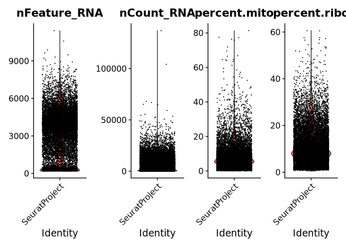

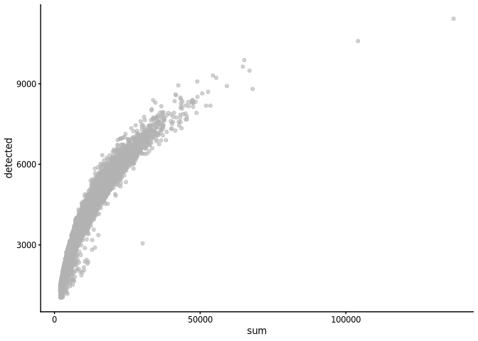

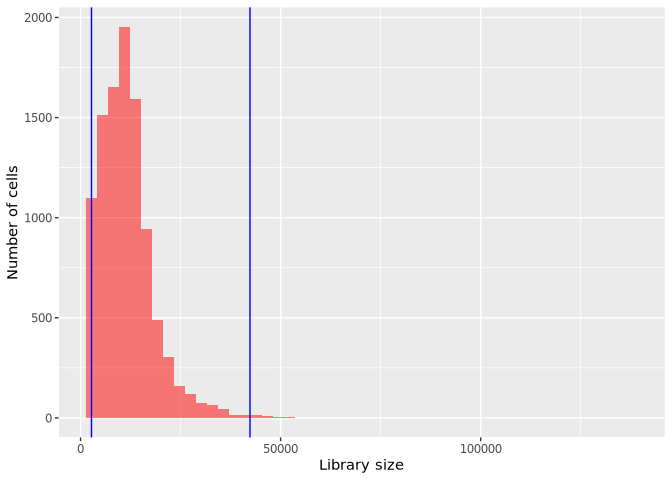

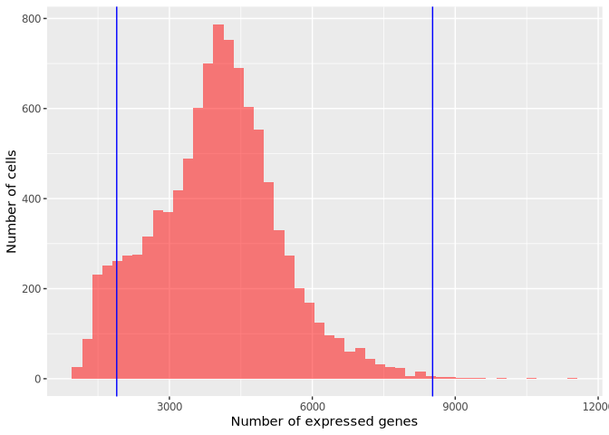

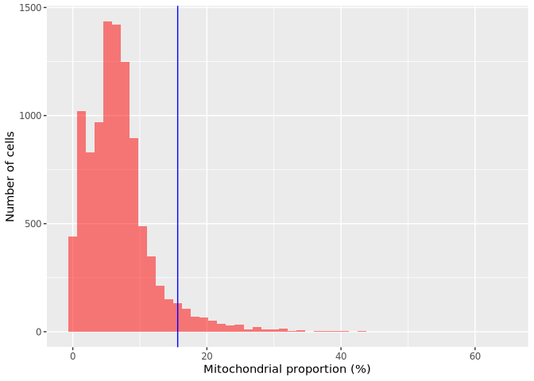

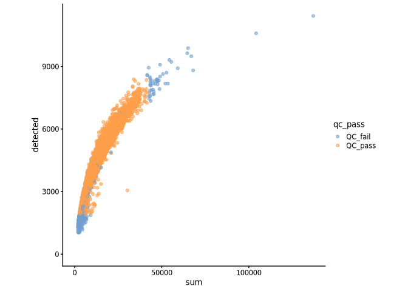

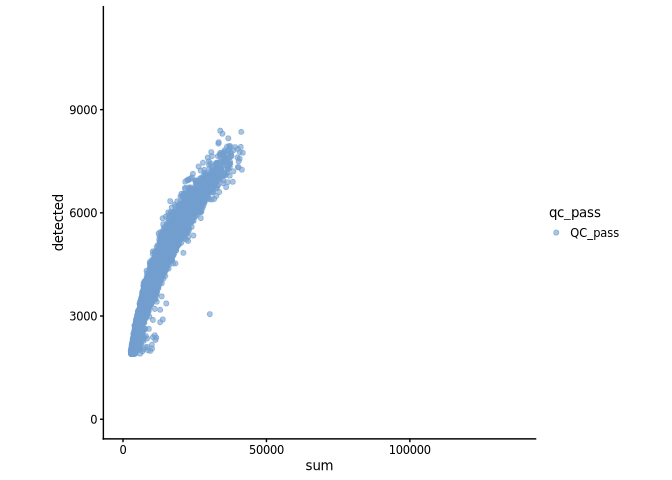

```
############# QC a/ filtering #############
```

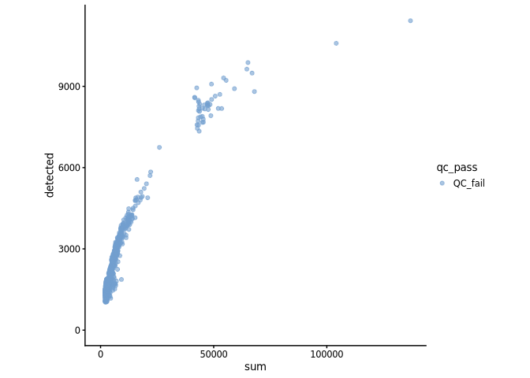

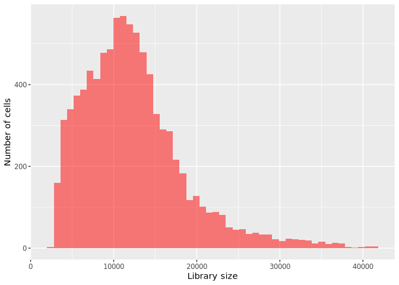

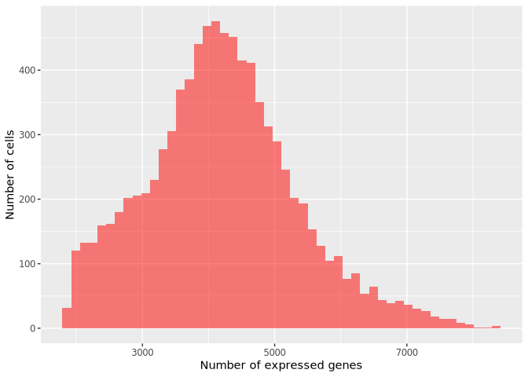

```
############# Additional QC metrics #############
```

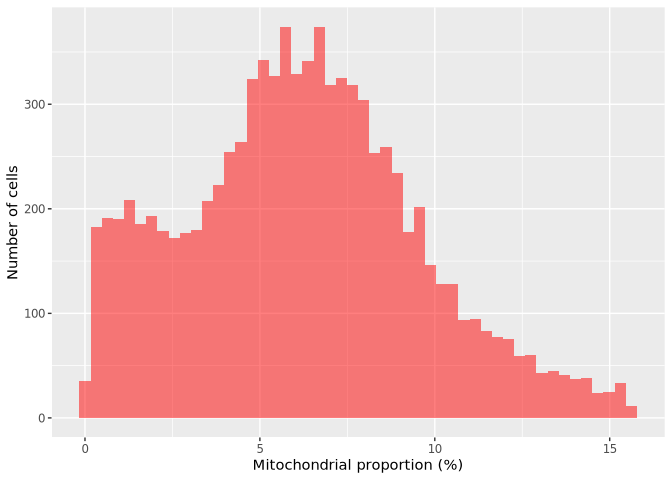

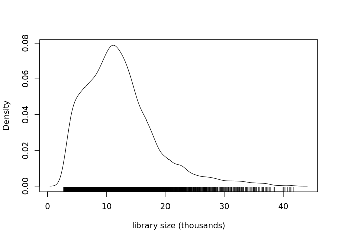

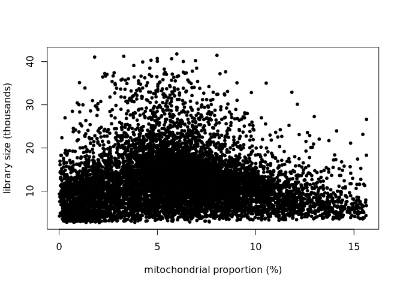

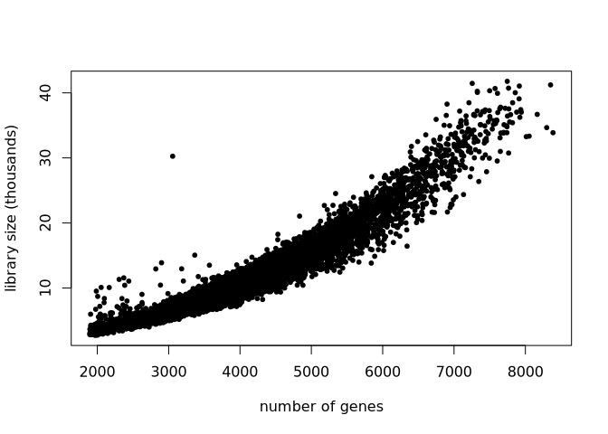

An object of class Seurat 17767 features across 8885 samples within 1 assay Active assay: RNA (17767 features, 0 variable features) 2 layers present: counts, data

**COp1_cell_10w_4dpi_wt2**

An object of class Seurat 17436 features across 11476 samples within 1 assay Active assay: RNA (17436 features, 0 variable features) 1 layer present: counts

```
############# QC b/ filtering #############
```

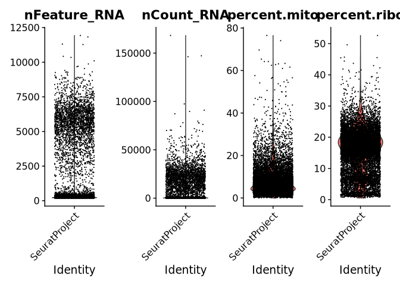

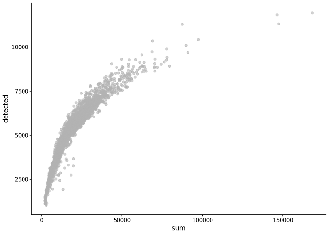

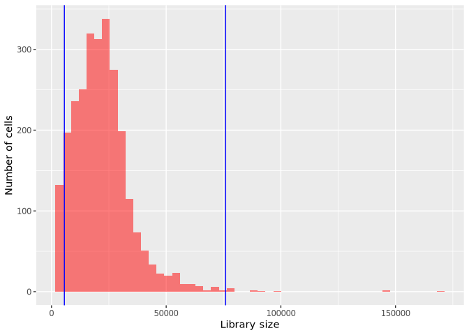

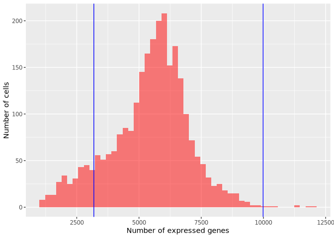

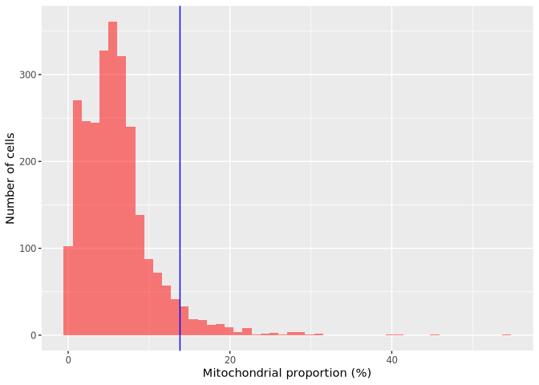

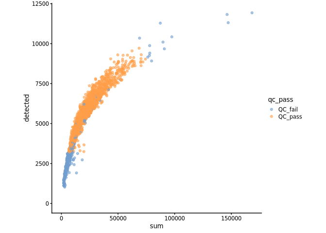

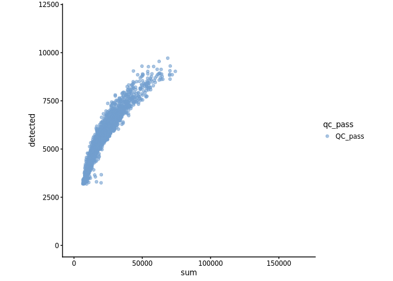

```
############# QC a/ filtering #############
```

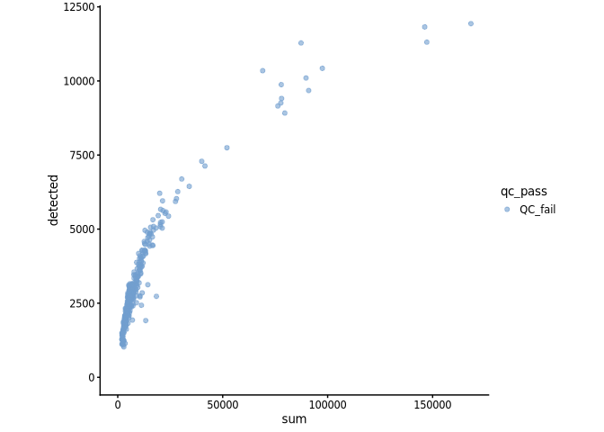

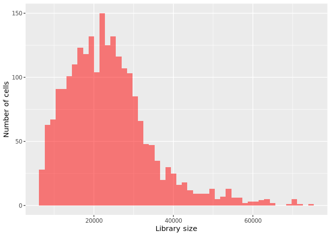

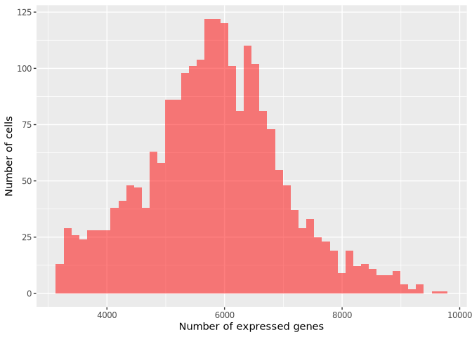

```
############# Additional QC metrics #############
```

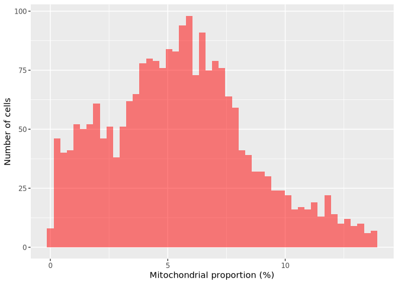

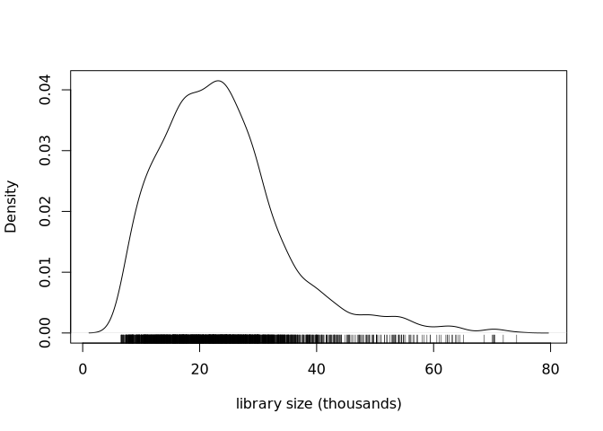

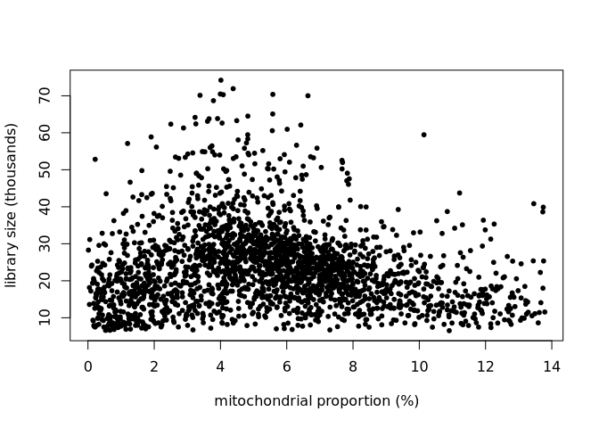

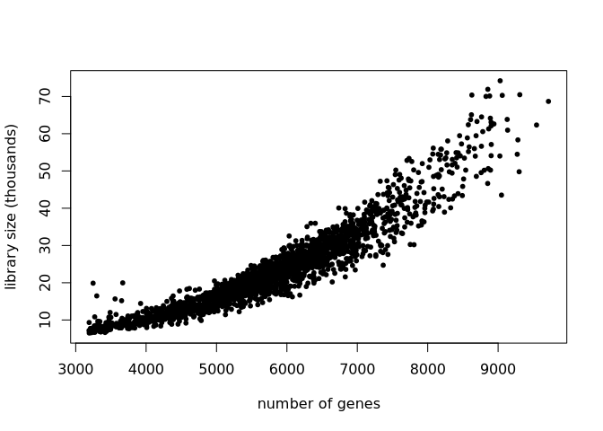

An object of class Seurat 17436 features across 2267 samples within 1 assay Active assay: RNA (17436 features, 0 variable features) 2 layers present: counts, data

**COp1_cell_4m_4dpi_mCh1**

An object of class Seurat 17468 features across 14331 samples within 1 assay Active assay: RNA (17468 features, 0 variable features) 1 layer present: counts

```
############# QC b/ filtering #############
```

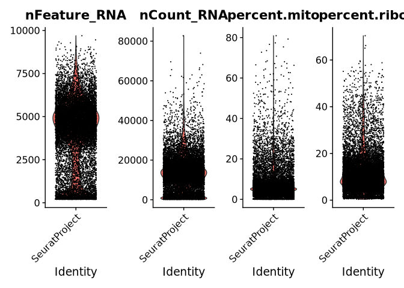

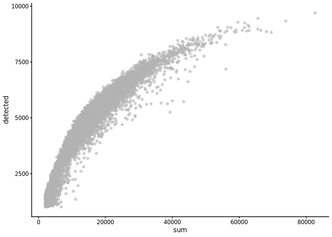

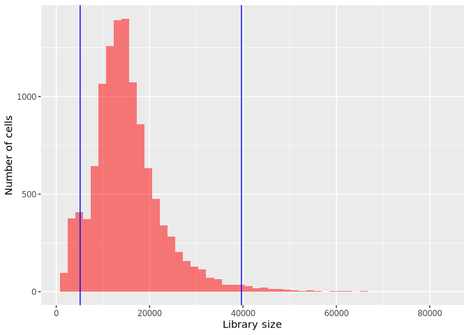

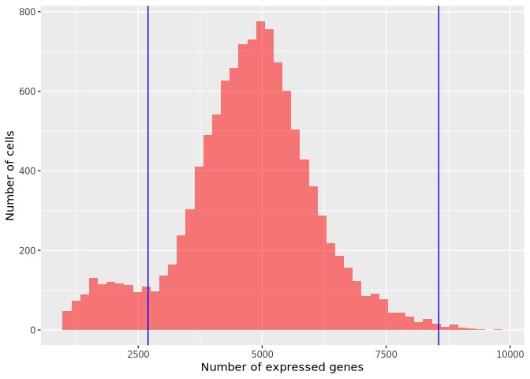

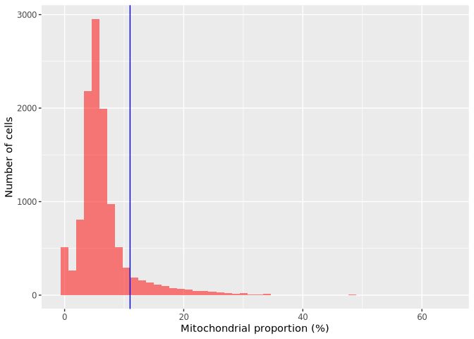

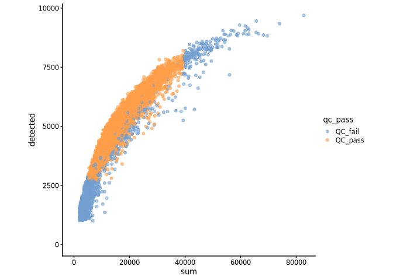

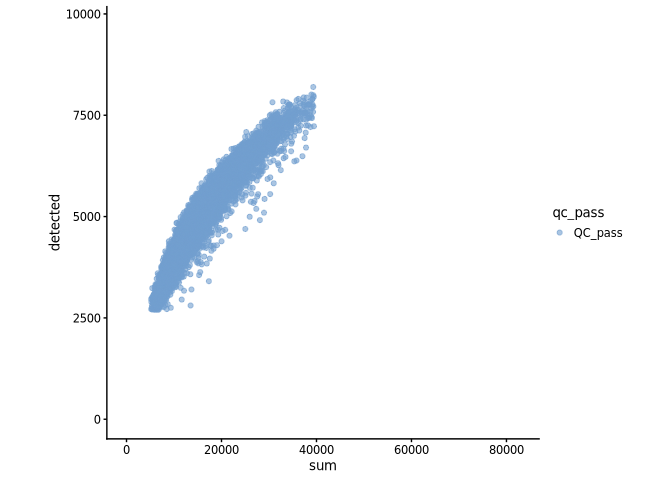

```
############# QC a/ filtering #############
```

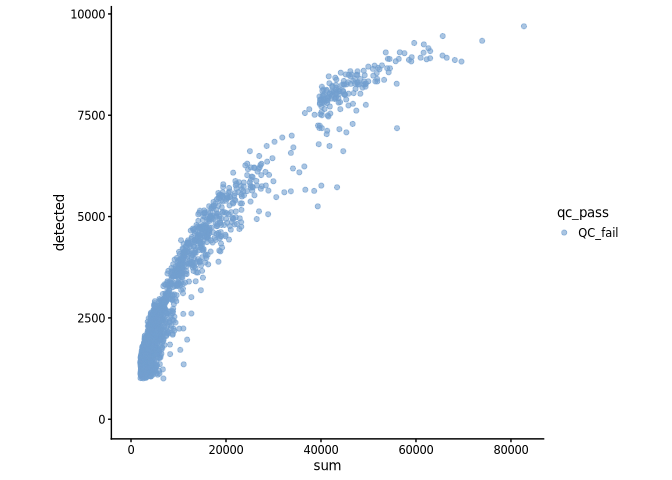

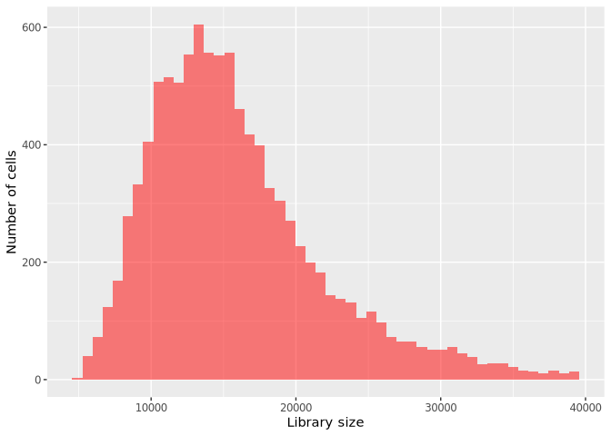

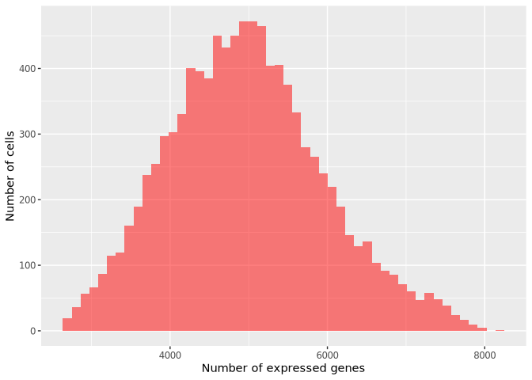

```
############# Additional QC metrics #############
```

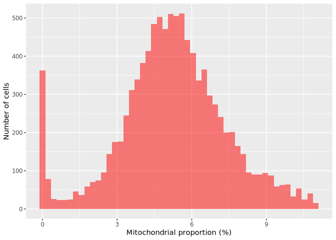

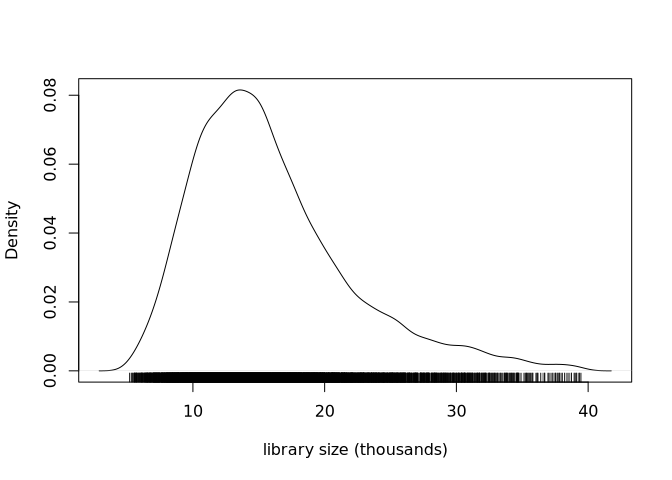

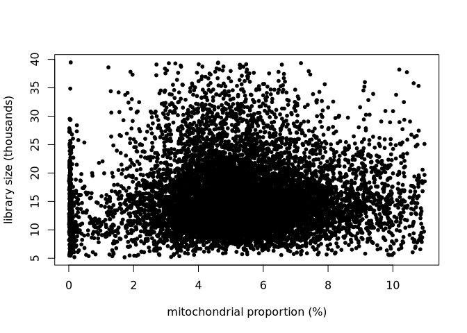

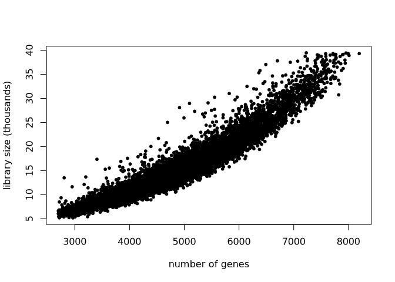

An object of class Seurat 17468 features across 9976 samples within 1 assay Active assay: RNA (17468 features, 0 variable features) 2 layers present: counts, data

**COp1_cell_4m_4dpi_mCh2**

An object of class Seurat 17499 features across 15543 samples within 1 assay Active assay: RNA (17499 features, 0 variable features) 1 layer present: counts

```
############# QC b/ filtering #############
```

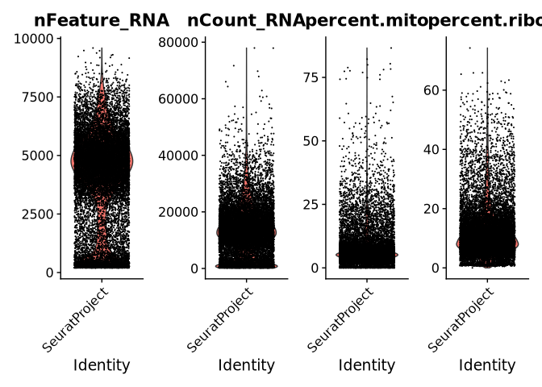

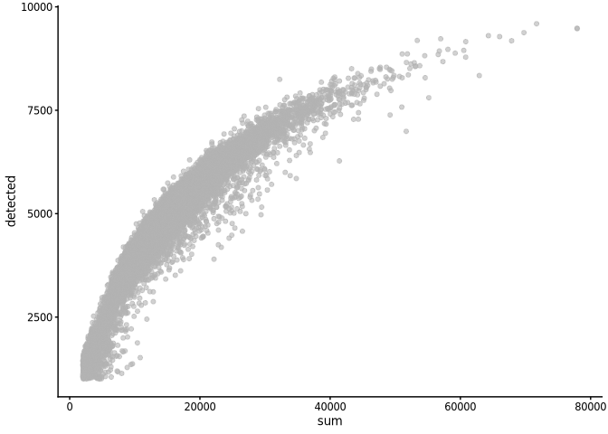

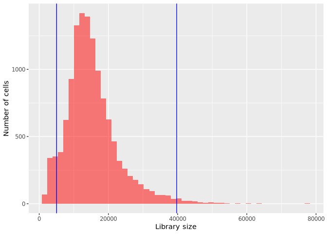

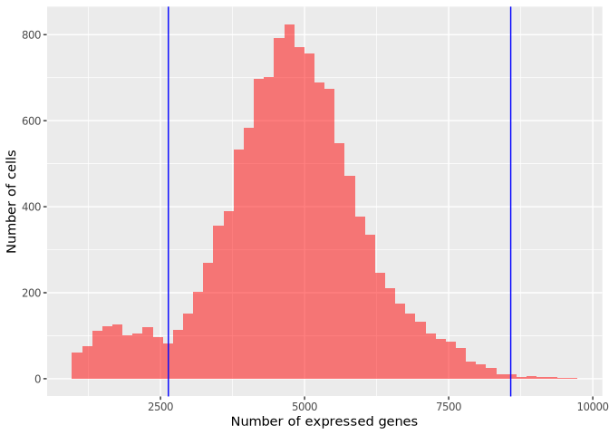

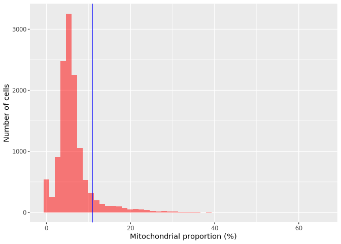

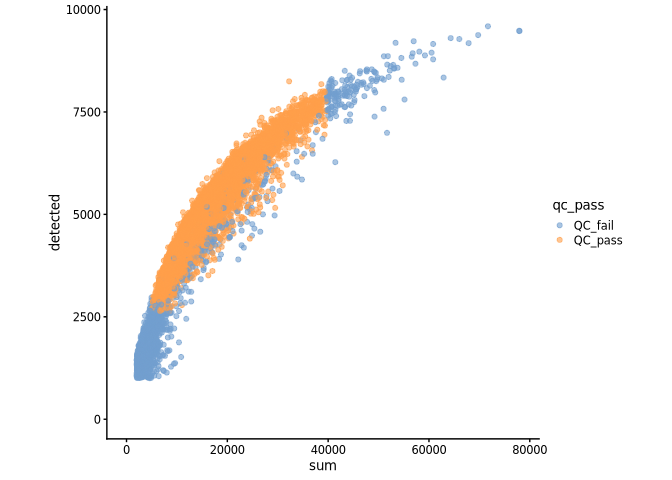

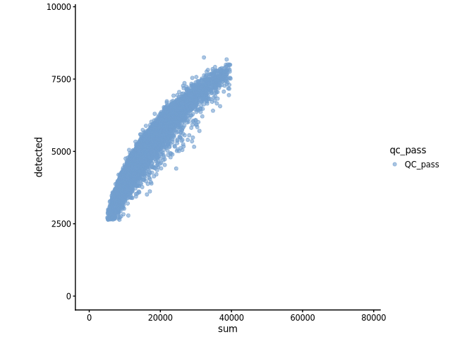

```
############# QC a/ filtering #############
```

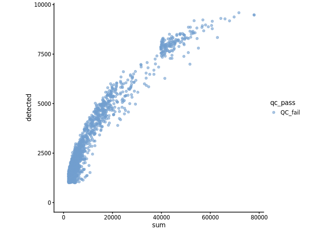

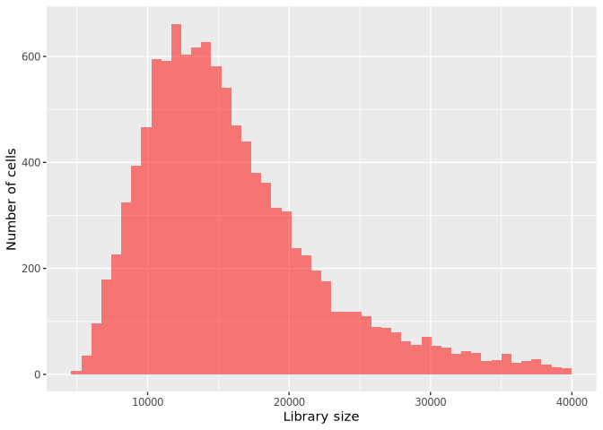

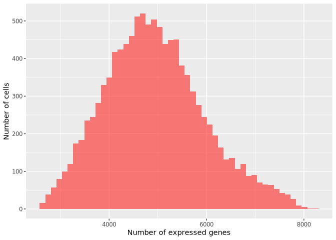

```
############# Additional QC metrics #############
```

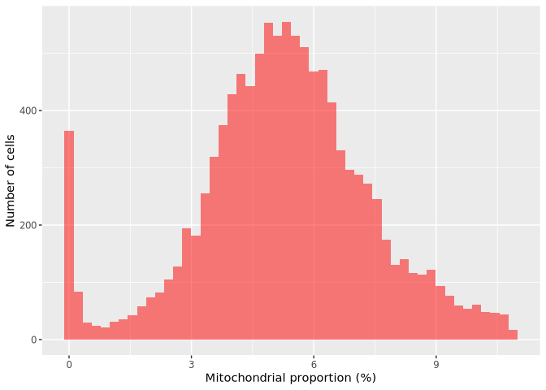

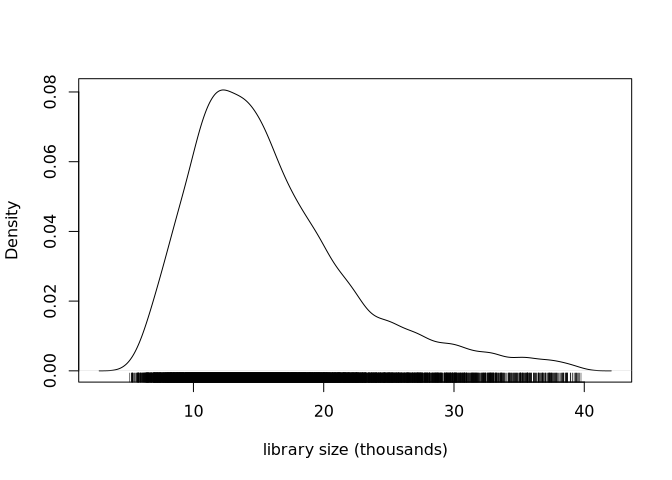

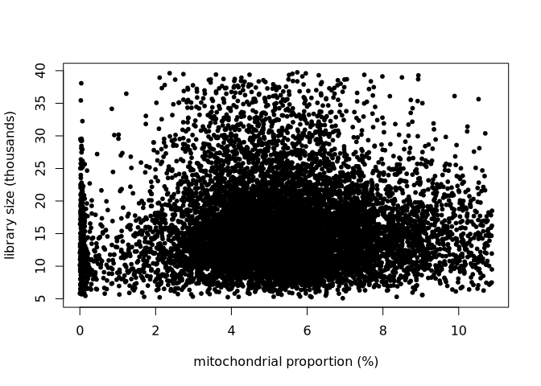

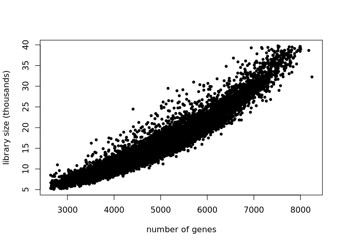

An object of class Seurat 17499 features across 11001 samples within 1 assay Active assay: RNA (17499 features, 0 variable features) 2 layers present: counts, data

**COp1_cell_4mo_4dpi_wt1**